# Veille pyplot Kablam Blanchard

Introduction

Matplotlib : c'est une librairie qui permet de tracer des graphes (dans le sens graphiques) : inspiré de Matlab au départ. inclus 2 façons de l'utiliser : soit avec une approche objet : plus compliquée et plus verbeuse, mais plus évoluée. soit via des appels de fonctions, avec pyplot : plus simple. pyplot fournit ainsi des raccourcis qui évitent la formulation objet plus longue à écrire. permet de faire des graphes qui peuvent être comlètement adaptés si besoin. Sur une figure, on peut tracer plusieurs graphes. permet aussi de dessiner. matplotlib rend ainsi possible la création de graphes à l'intérieur d'applications complexes autorisées par le langage python, et ceci sans quitter le langage python. Notions principales pour les graphes sous matplotlib : figure : une figure qui peut être sauvée dans un fichier. axe : un graphe (graphique) individuel appartenant à une figure qui peut en compter plusieurs. Attention, ce n'est pas un axe de coordonnées ! axis : un axe de coordonnées appartenant à un objet axe. divers objets graphiques qui dérivent de la classe Artist et qui participent au graphe. Ce sont par exemple des rectangles, des lignes, du texte. Ces différents objets peuvent être totalement configurés (y compris individuellement) pour adapter le graphe aux besoins en appelant dessus des méthodes pour modifier leurs propriétés !

Matplotlib est probablement le package Python le plus utilisé pour les graphiques 2D. Il fournit à la fois un moyen rapide de visualiser les données de Python et des chiffres de qualité de publication dans de nombreux formats. Nous allons explorer matplotlib en mode interactif couvrant les cas les plus courants.

```python
%matplotlib inline
# Pour les sessions matplotlib interactives, activez le mode matplotlib
```

Pyplot

pyplot fournit une interface procédurale à la bibliothèque de tracé orientée objet matplotlib. Il est calqué de près sur l™ Matlab. Par conséquent, la majorité des commandes de traçage dans pyplot ont des analogues ™ Matlab avec des arguments similaires. Les commandes importantes sont expliquées avec des exemples interactifs.

pyplot et généralités Importation du module : from matplotlib import pyplot. Pour tracer un graphe x-y avec les points reliés (pour un nuage de points, utiliser plutôt scatter) : from matplotlib import pyplot : pour importer le module. pour tracer un graphe avec des valeurs de x et des valeurs de y en reliant les points dans l'ordre de la liste : pyplot.plot([1, 2, 3, 6], [1, 4, 9, 36]) pyplot.show() : montre le graphe courant. on peut indiquer le symbole et la couleur : pyplot.plot(x, y, 'bo') : bleu et avec des ronds. on peut aussi indiquer tous les paramètres avec des tags séparés : pyplot.plot(x, y, color = 'green', linestyle = 'dashed', linewidth = 2, marker = 'o', markerfacecolor = 'blue', markersize = 5) : symboles ronds en bleu avec une taille de 5 et traits pointillés en vert. pyplot.plot(x, y, label = 'A') : permet de mettre un label sur la courbe !!! on peut tracer plusieurs courbes sur le même graphe : pyplot.plot(x, y, 'r+', y, y, 'bo') si on a un objet AxesSubplot, on peut tracer dessus un graphe en faisant : axes.plot(...)

Manipulation d'un graphe : on peut récupérer les limites des axes par : ax.get_xlim(), ax.get_ylim() on peut fixer les limites des axes par : ax.set_xlim(), ax.set_ylim() on peut récupérer le titre d'un axe par : ax.get_title() on peut fixer le titre d'un axe par : ax.set_title() Sauvegarde de l'image dans un fichier : pyplot.savefig('image.png'); pyplot.close().

```python
from matplotlib import pyplot as plt
```

Traçage avec les paramètres par défaut Matplotlib est livré avec un ensemble de paramètres par défaut qui permettent de personnaliser toutes sortes de propriétés. Vous pouvez contrôler les valeurs par défaut de presque toutes les propriétés de matplotlib: taille de la figure et dpi, largeur de ligne, couleur et style, axes, propriétés d’axe et de grille, propriétés de texte et de police, etc.

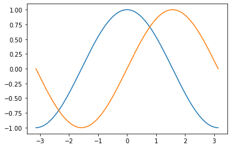

```python
import numpy as np
import matplotlib.pyplot as plt

X = np.linspace(-np.pi, np.pi, 256)
C, S = np.cos(X), np.sin(X)

plt.plot(X, C)
plt.plot(X, S)

plt.show()
```

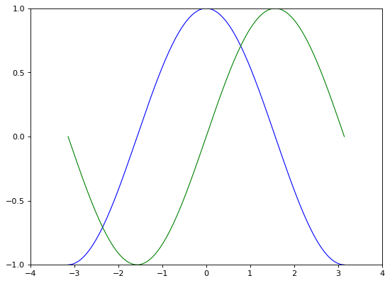

```python
import numpy as np
import matplotlib.pyplot as plt

# Create a figure of size 8x6 inches, 80 dots per inch
plt.figure(figsize=(8, 6), dpi=80)

# Create a new subplot from a grid of 1x1
plt.subplot(1, 1, 1)

X = np.linspace(-np.pi, np.pi, 256)
C, S = np.cos(X), np.sin(X)

# Plot cosine with a blue continuous line of width 1 (pixels)
plt.plot(X, C, color="blue", linewidth=1.0, linestyle="-")

# Plot sine with a green continuous line of width 1 (pixels)
plt.plot(X, S, color="green", linewidth=1.0, linestyle="-")

# Set x limits
plt.xlim(-4.0, 4.0)

# Set x ticks
plt.xticks(np.linspace(-4, 4, 9))

# Set y limits
plt.ylim(-1.0, 1.0)

# Set y ticks
plt.yticks(np.linspace(-1, 1, 5))

# Save figure using 72 dots per inch
# plt.savefig("exercise_2.png", dpi=72)

# Show result on screen
plt.show()
```

https://scipy-lectures.org/intro/matplotlib/index.html

```python
help(plt.plot) # documentation
```

[output not shown]

[output cut: 229 more lines]

[output not shown]

```python
from IPython.display import Image
```

Propriétés de la ligne

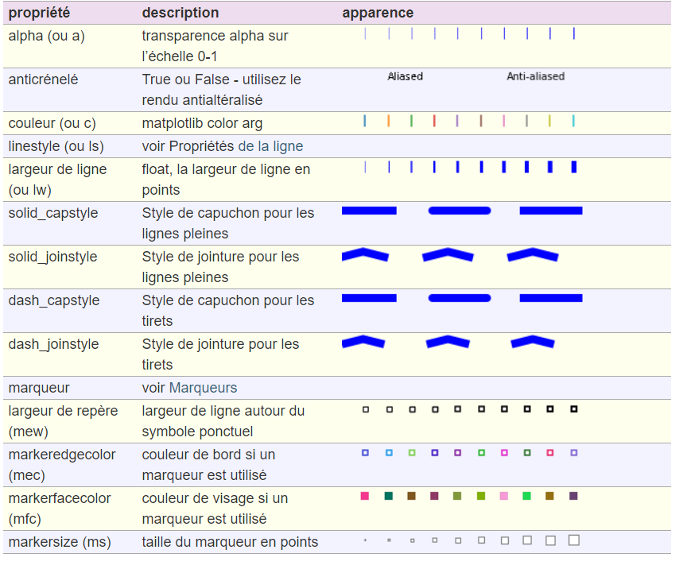

```python
PATH = "C:\\Users\\Simplonco\\Downloads\\"
Image(filename = PATH + "Capture3.PNG", width=1000, height=1000)
```

Exemples de code complet

# Bar plots

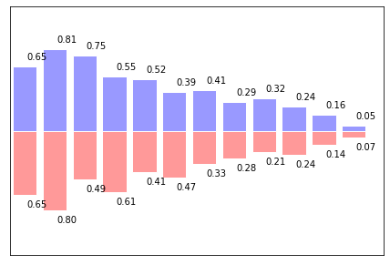

```python
import numpy as np
import matplotlib.pyplot as plt

n = 12
X = np.arange(n)
Y1 = (1 - X / float(n)) * np.random.uniform(0.5, 1.0, n)
Y2 = (1 - X / float(n)) * np.random.uniform(0.5, 1.0, n)

plt.axes([0.025, 0.025, 0.95, 0.95])
plt.bar(X, +Y1, facecolor='#9999ff', edgecolor='white')
plt.bar(X, -Y2, facecolor='#ff9999', edgecolor='white')

for x, y in zip(X, Y1):
    plt.text(x + 0.4, y + 0.05, '%.2f' % y, ha='center', va= 'bottom')

for x, y in zip(X, Y2):
    plt.text(x + 0.4, -y - 0.05, '%.2f' % y, ha='center', va= 'top')

plt.xlim(-.5, n)
plt.xticks([])
plt.ylim(-1.25, 1.25)
plt.yticks([])

plt.show()
```